# Влияние кризиса 2008 года на различные страны и/или регионы

#### Соединенные Штаты - страна-зачинщик кризиса

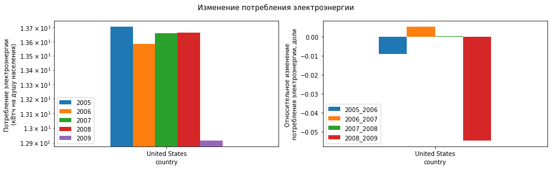

```python
show_electric(['United States'], legend_loc1=3)
```

- В США кризис ощутимо снизил потребление электроэнергии.

#### Развитые страны Европы: Великобритания

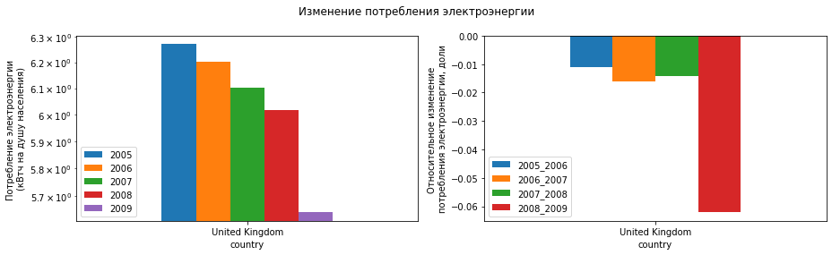

```python
show_electric(['United Kingdom'], legend_loc1=3)
```

- В Великобритании видим похожую с США картину. Потребление электроэнергии уменьшалось с каждым годом, кризис наблюдаем в ощутимом снижении энергопотребления.

#### Развитые страны Европы: Норвегия и Швейцария

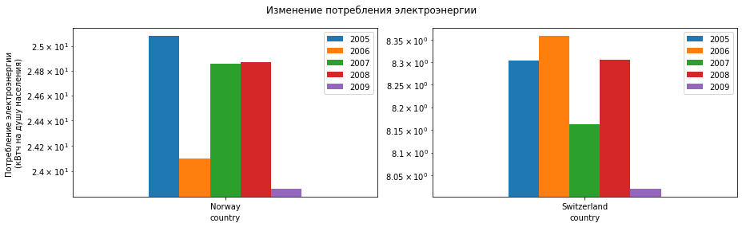

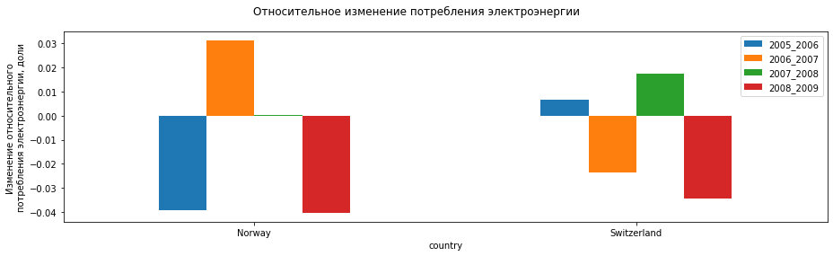

```python
show_electric_1(['Norway', 'Switzerland'])
show_electric_2(['Norway', 'Switzerland'])
```

- У развитых стран Европы кризис оказал влияние на уровень потребления электроэнергии - в 2009 году видим заметное снижение.

#### Бедные страны Европы: Босния и Герцеговина

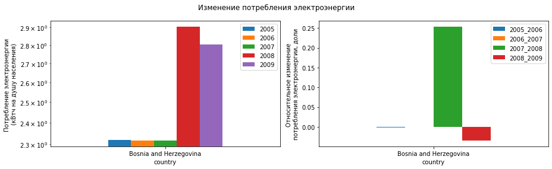

```python
show_electric(['Bosnia and Herzegovina'])
```

#### Страны СНГ: Украина, Российская Федерация, Республика Молдова

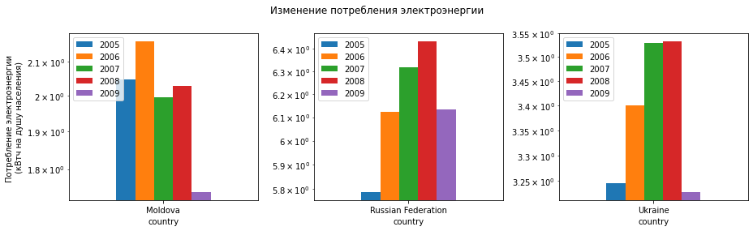

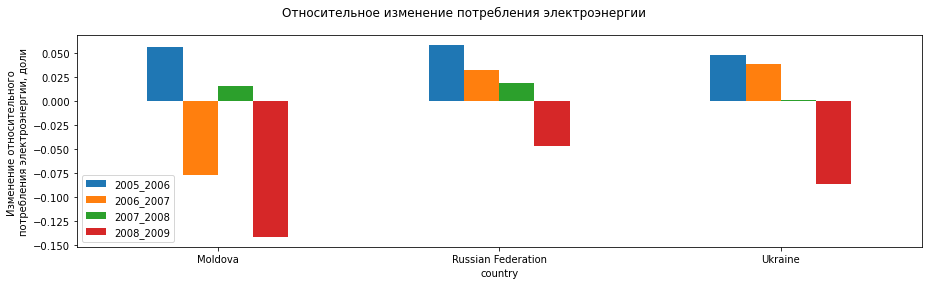

```python
show_electric_1(CIS, legend_loc1=2)
show_electric_2(CIS)
```

- Страны СНГ в кризис по потреблению электроэнергии повели себя как развитые страны Европы и США: уроверь потребления ощутимо снизился в год после кризиса.

#### Развитые страны Азии: Китай и Гонконг, Япония

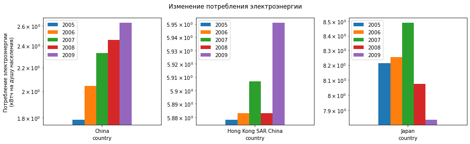

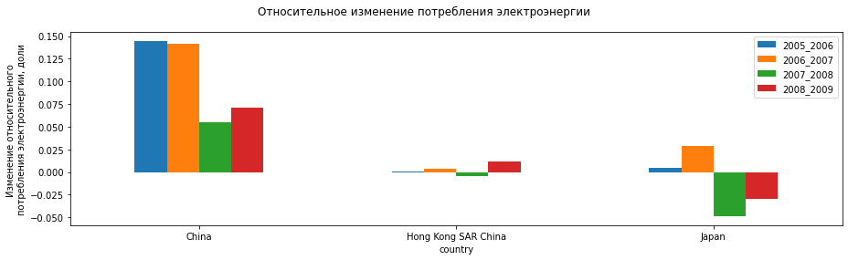

```python
show_electric_1(RICH_ASIA, legend_loc1=2)
show_electric_2(RICH_ASIA)
```

- Китай в период кризиса не сократил своего энергопотребления, только снизил темпы его прироста.
- Для Гонконга в послекризистный период было время прироста электропотребления.
- Япония в отличие от остальных ощутимо снизила свое электропотребление в 2008-2009 - поведение больше похоже на развитые страны Европы и США.

#### Бедные страны Азии: Камбоджа и Бангладеш

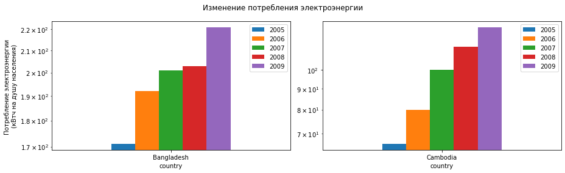

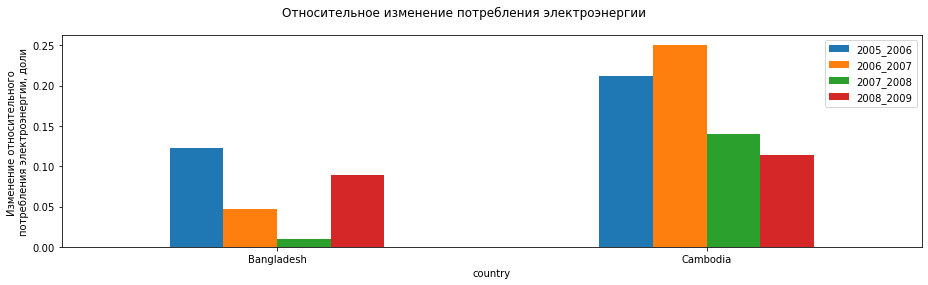

```python
show_electric_1(POOR_ASIA)
show_electric_2(POOR_ASIA)
```

- Бедные страны Азии в 2005-2009 году приращивали потребление электроэнергии, но по-разному отреагировали на кризис: в Бангладеше кризис поднял темпы прироста потребления электроэнерги, а в Камбодже наоборот снизил.

#### Развитые страны Азии : Персидский залив, Саудовская Аравия

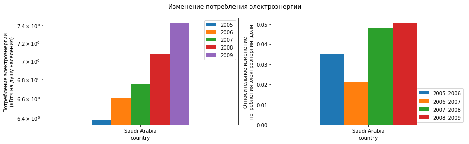

```python
show_electric(['Saudi Arabia'], legend_loc2=4)
```

Для Саудовской Аравии нет заметного влияния кризиса на потребление электроэнергии, нефтяной гигант в 2005-2009 гг наращивал потребление.

### **Отчет по влиянию кризиса 2008 г на импорт энергии**

Подготовим списки исследуемых параметров.

```python
ENERGY_IMPORT_CHANGE_LIST = ['energy_imports_2005_2006', 'energy_imports_2006_2007', 'energy_imports_2007_2008', 'energy_imports_2008_2009']
ENERGY_IMPORT_LIST = ['energy_imports_2005', 'energy_imports_2006', 'energy_imports_2007', 'energy_imports_2008', 'energy_imports_2009']
```

Рассмотрим, как сказался кризис на импорт энергии выбранных стран.

Напишем функции для визуализации графиков.

```python
def show_energy_import(countries, legend_loc1=0, legend_loc2=0, figsize=(13, 4), subplots=[1, 2]):
    fig, axes = plt.subplots(subplots[0], subplots[1], figsize=figsize)
    short.loc[short.index.isin(countries)][ENERGY_IMPORT_LIST].plot(kind='bar',
                                                           ax=axes[0],
                                                           rot=0)
    axes[0].legend(LEGEND_YEAR, loc=legend_loc1)

    axes[0].set_ylabel('Импорт энергии, нетто \n(% от потребления энергии)')
    short.loc[short.index.isin(countries)][ENERGY_IMPORT_CHANGE_LIST].plot(kind='bar',
                                                                  ax=axes[1],
                                                                  rot=0)
    axes[1].legend(LEGEND_YEAR_YEAR, loc=legend_loc2)
    axes[1].set_ylabel('Относительное изменение \nимпорта энергии')
    plt.suptitle(f'Изменение импорта энергии')
    plt.tight_layout()
    plt.show()
```

```python
def show_energy_import_1(countries, legend_loc1=0, legend_loc2=0, figsize=(13, 4)):
    fig, axes = plt.subplots(1, 1, figsize=figsize)
    short.loc[short.index.isin(countries)][ENERGY_IMPORT_LIST].plot(kind='bar',
                                                                        ax=axes,
                                                                        rot=0)
    axes.legend(LEGEND_YEAR, loc=legend_loc2)
    axes.set_ylabel('Импорт энергии, нетто \n(% от потребления энергии)')
    plt.suptitle(f'Изменение импорта энергии')
    plt.tight_layout()
    plt.show()
```

```python
def show_energy_import_2(countries, legend_loc1=0, legend_loc2=0, figsize=(13, 4)):
    fig, axes = plt.subplots(1, 1, figsize=figsize)
    short.loc[short.index.isin(countries)][ENERGY_IMPORT_CHANGE_LIST].plot(kind='bar',
                                                                        ax=axes,
                                                                        rot=0)
    axes.legend(LEGEND_YEAR_YEAR, loc=legend_loc2)
    axes.set_ylabel('Изменение относительного \nимпотра энергии')
    plt.suptitle(f'Относительное изменение импорта энергии')
    plt.tight_layout()
    plt.show()
```

Приступим к исследованию выбранных стран.

#### Соединенные Штаты - страна-зачинщик кризиса

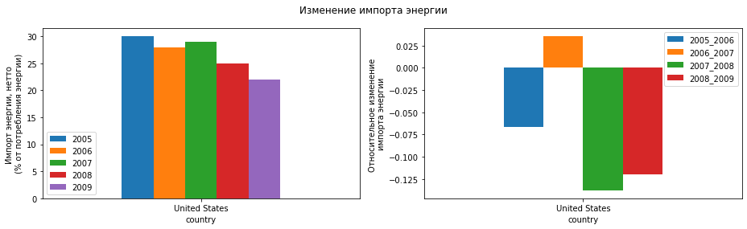

```python
show_energy_import(['United States'], legend_loc1=3)
```

```python
short.loc['United States'][ENERGY_IMPORT_LIST]
```

```
energy_imports_2005    30.0
energy_imports_2006    28.0
energy_imports_2007    29.0
energy_imports_2008    25.0
energy_imports_2009    22.0
Name: United States, dtype: object
```

- Содениненные Штаты достаточно аткивно понижали импорт энергии в 2007-2009 годах: с 29% в 2007 г. до 25% в 2008 г. и до 22% в 2009 г.

#### Развитые страны Европы: Великобритания

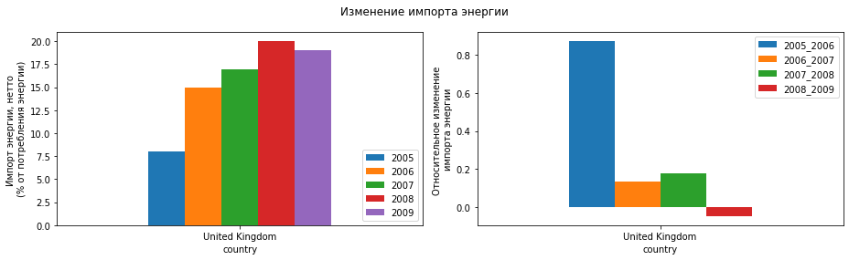

```python
show_energy_import(['United Kingdom'], legend_loc1=4)
```

```python
short.loc['United Kingdom'][ENERGY_IMPORT_LIST]
```

```
energy_imports_2005     8.0
energy_imports_2006    15.0
energy_imports_2007    17.0
energy_imports_2008    20.0
energy_imports_2009    19.0
Name: United Kingdom, dtype: object
```

- Великобритания наращивала импорт энергии в исследуемые года. В 2006 году Великобритания практически удвоила импорт энергии с 8% в 2005 г. до 15%. В 2009 г. импорт снизился по стравнению с 2008 г.

#### Развитые страны Европы: Норвегия и Швейцария

В данном случае мы разделим эти страны: Норвегия является экспортером энергии и на общей шкале обе страны будут выглядеть не очень корректно.

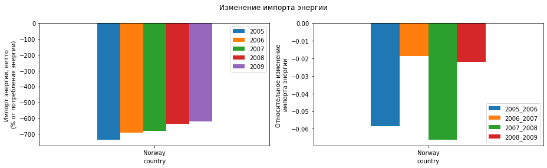

```python
show_energy_import(['Norway'], legend_loc2=4)
```

```python
short.loc['Norway'][ENERGY_IMPORT_LIST]
```

```
energy_imports_2005   -736.0
energy_imports_2006   -693.0
energy_imports_2007   -680.0
energy_imports_2008   -635.0
energy_imports_2009   -621.0
Name: Norway, dtype: object
```

- Для Норвегии 2005-2009 гг. были годами понижения уровня экспорта энергии: с 736% от потребляемой электроэнергии в 2005 г до 621% в 2009 г. Кризис замедлил скорость понижения уровня экспорта.

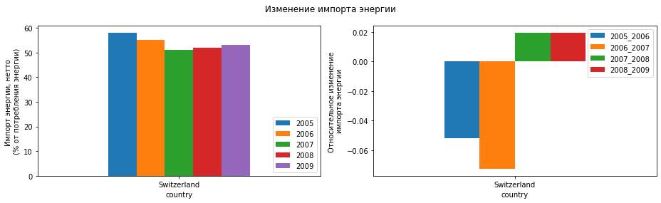

```python
show_energy_import(['Switzerland'], legend_loc1=4)
```

```python
short.loc['Switzerland'][ENERGY_IMPORT_LIST]
```

```
energy_imports_2005    58.0
energy_imports_2006    55.0
energy_imports_2007    51.0
energy_imports_2008    52.0
energy_imports_2009    53.0
Name: Switzerland, dtype: object
```

- Швейцария до 2007 года незначительно понижала уроверь импорта энергии, после 2007 импорт начал незначительно увеличиваться.

#### Бедные страны Европы: Босния и Герцеговина

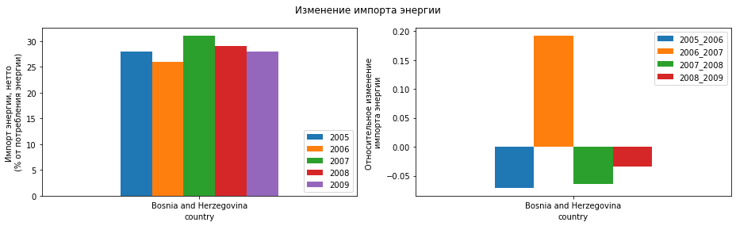

```python
show_energy_import(['Bosnia and Herzegovina'], legend_loc1=4)
```

- Босния и Герцеговина повысили свой импорт энергии в 2007 году и после этого начали плавно его снижать.

#### Страны СНГ: Украина, Российская Федерация, Республика Молдова

Рассмотрим отдельно Украину и Республику Молдову и Россию, так как Россия - экспортер энерги.

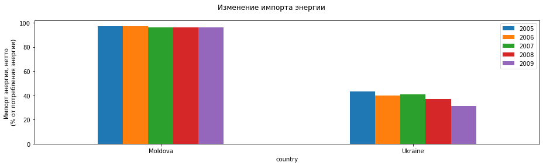

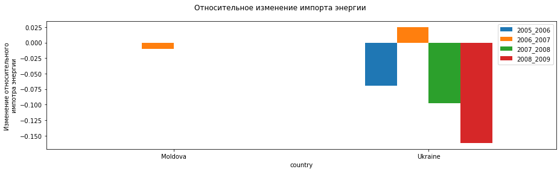

```python
show_energy_import_1(['Moldova', 'Ukraine'])
show_energy_import_2(['Moldova', 'Ukraine'])
```

```python
short.loc['Ukraine'][ENERGY_IMPORT_LIST]
```

```
energy_imports_2005    43.0
energy_imports_2006    40.0
energy_imports_2007    41.0
energy_imports_2008    37.0
energy_imports_2009    31.0
Name: Ukraine, dtype: object
```

- Молдова импортировала почти всю потребляемую энергию, и кризис не изменил этого, разве что в 2007 г уровень импорта незначительно понизился.
- Украина импортировала около 40% потребляемой энергии. В кризис и после него уроверь импорта ощутимо снижался: с 41% в 2007 г до 31% в 2009 г.

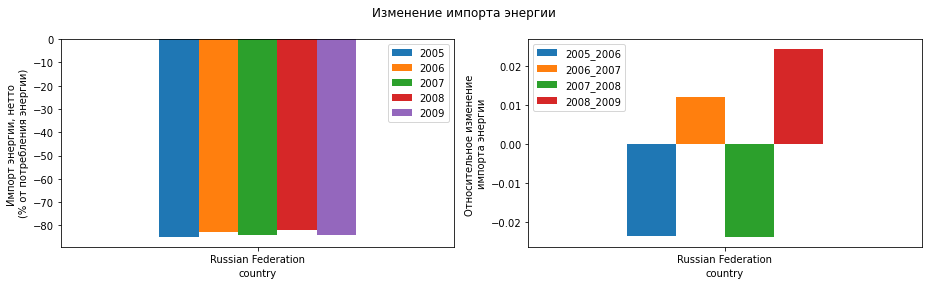

```python
show_energy_import(['Russian Federation'], legend_loc2=2)
```

```python
short.loc['Russian Federation'][ENERGY_IMPORT_LIST]
```

```
energy_imports_2005   -85.0
energy_imports_2006   -83.0
energy_imports_2007   -84.0
energy_imports_2008   -82.0
energy_imports_2009   -84.0
Name: Russian Federation, dtype: object
```

- Российская Федерация в 2005-2009 гг экспортировала чуть более 80% от потребляемой энергии. Видим, что в эти годы показатели экспорта испытывали незначительные колебания.

#### Развитые страны Азии: Китай и Гонконг, Япония

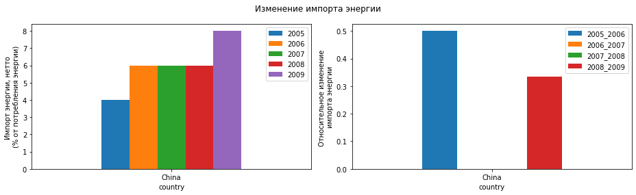

```python
show_energy_import(['China'])
```

```python
short.loc['China'][ENERGY_IMPORT_LIST]
```

```
energy_imports_2005    4.0
energy_imports_2006    6.0
energy_imports_2007    6.0
energy_imports_2008    6.0
energy_imports_2009    8.0
Name: China, dtype: object
```

- Импорт энергии Китаем в 2006-2008 году был очень стабильным - около 6%, после кризиса вырос до 8%.

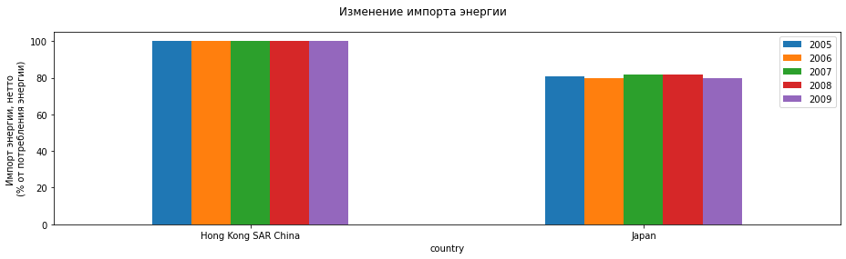

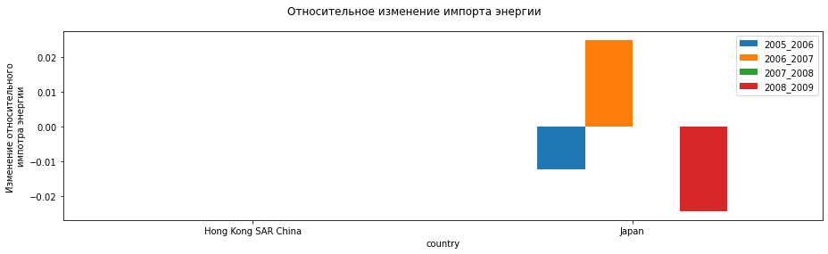

```python
show_energy_import_1(['Hong Kong SAR China', 'Japan'])
show_energy_import_2(['Hong Kong SAR China', 'Japan'])
```

- В исследуемые годы Гонконг импортировал всю потребляемую энергию.
- Япония импортировала порядка 80% потребляемой энегрии в исследуемые годы. Кризис понизил имппорт энергии в 2009 году.

#### Бедные страны Азии: Камбоджа и Бангладеш

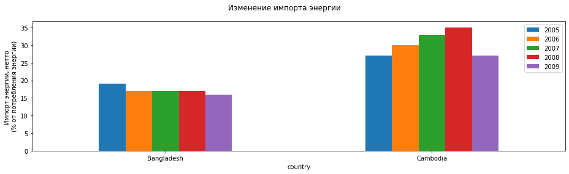

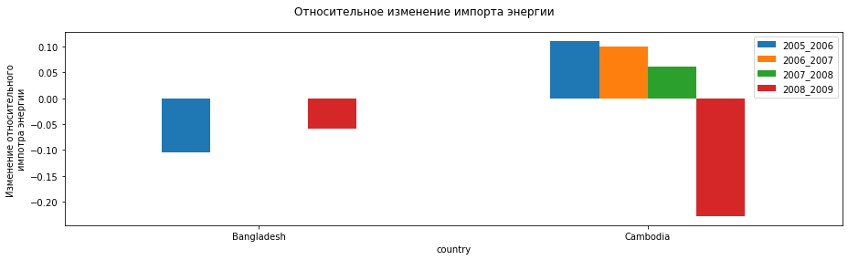

```python
show_energy_import_1(POOR_ASIA)
show_energy_import_2(POOR_ASIA)
```

- Бангладеш импортировал до 20% потребляемой энергии в исследуемые годы, кризис слегка снизил импорт 2009 г.
- Камбоджа наращивала импорт энергии до кризиса, после кризиса импорт упал до уровня 2005 года.

#### Развитые страны Азии : Персидский залив, Саудовская Аравия

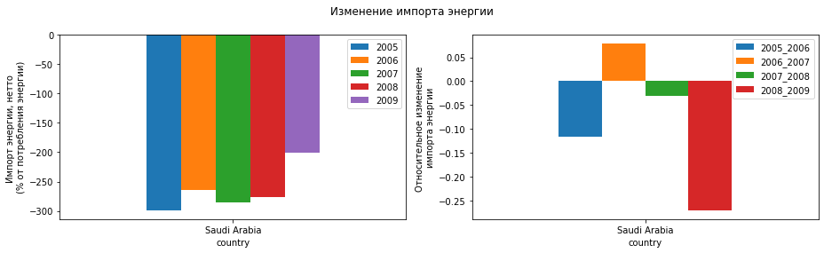

```python
show_energy_import(['Saudi Arabia'])
```

```python
short.loc['Saudi Arabia'][ENERGY_IMPORT_LIST]
```

```
energy_imports_2005   -299.0
energy_imports_2006   -264.0
energy_imports_2007   -285.0
energy_imports_2008   -276.0
energy_imports_2009   -201.0
Name: Saudi Arabia, dtype: object
```

- Для нефтяного гиганта кризис значительно сократил экспорт энергии. Если в 2008 г экспорт составлял 276%, то в 2009 г уже 201%.

#### **Вывод**

На основании исследования влияния кризиса на импорт энергии отдельных стран можно сделать следующие выводы:

- Мы исследовали трех **экспортеров энергии**:
  - Саудовская Аравия: экспорт энергии в кризисное время значительно снизился: на 75% от потребляемой электроэнергии (в 2008 г экспорт составлял 276%, то в 2009 г - 201%).
  - Норвегия: постепенно снижала экспорт энергии в течение всего исследуемого времени.
  - Российская Федерация: кризис не отразился на объемах экспорта энергии, в иссдедуемые годы экспортировала более 80% от потребляемой электроэнергии.
- Для **стран-импортеров энергии** было выяснено:
  - Соединенные Штаты в кризисный период сократили импорт энергии с 29% от потребляемой энергии до 22%.
  - На Великобритании кризис почти не отразился, в 2006 году она практически удвоила импорт энергии с 8% до 15%, однако в 2009 г импорт начал уменьшаться после кризиса. Импорт в кризисное время составлял около 20%.
  - Колебания импорта энергии для Швейцарии и Боснии и Герцеговины были достаточно небольшие.
  - Украина импортировала около 40% потребляемой энергии. В кризис и после него уроверь импорта ощутимо снижался: с 41% в 2007 г до 31% в 2009 г.
  - На Японии, Камбодже и Бангладеше влияние кризиса проявилось снижением импорта энергии. На Камбодже кризис отразился сильнее.
  - Китай оказался единственной исследованной азиатской страной, для которой кризис проявился в повышении импорта энегрии в условиях кризиса. В 2008 г Китай импортировал 6% энергии, в 2009 г - 8%.
  - Так же у нас две страны со значительным уровнем импорта:
    - Республика Молдова - до 2007 г импортировала 97% потребляемой энергии, после 2007 г - 96%.
    - Гонконг - импортировал 100% потребляемой энергии.

### **Отчет по влиянию кризиса 2008 г на изменение ВВП**

Подготовим списки исследуемых параметров.

```python
GDP_CHANGE_LIST = ['gdp_2005_2006', 'gdp_2006_2007', 'gdp_2007_2008', 'gdp_2008_2009']
GDP_LIST = ['gdp_2005', 'gdp_2006', 'gdp_2007', 'gdp_2008', 'gdp_2009']
```

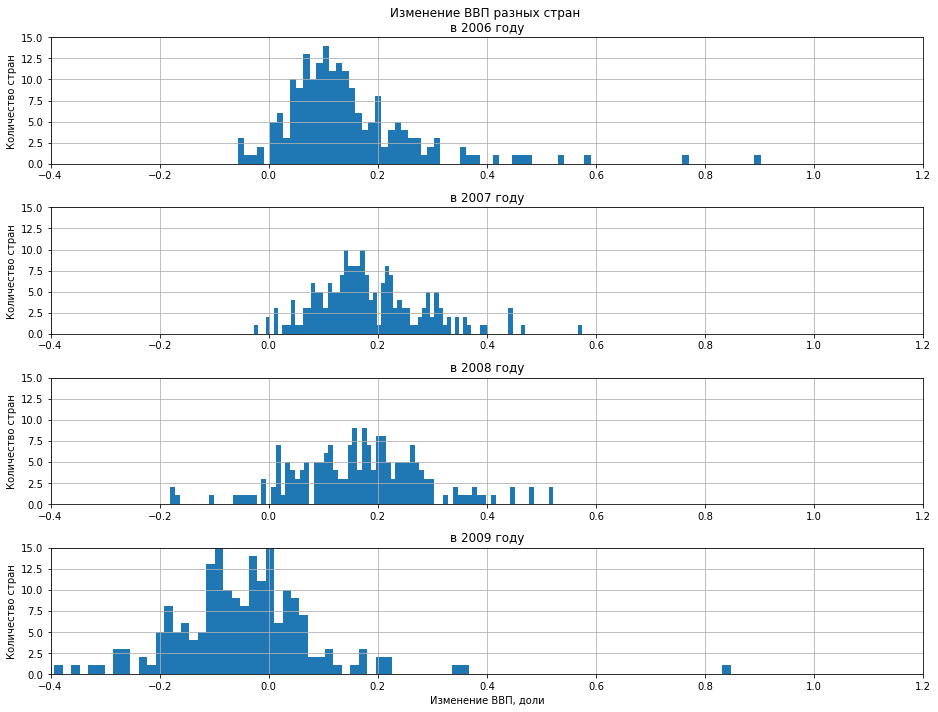

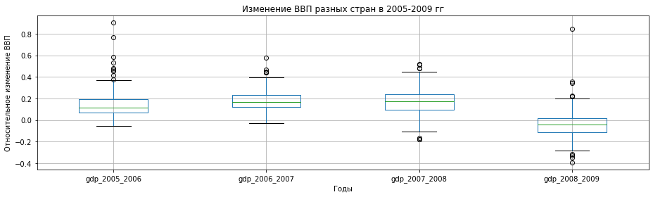

```python
BINS = 80
fig, axes = plt.subplots(4,
                         1,
                         figsize=(13, 10)
                        )

df.gdp_2005_2006.hist(bins=BINS, ax=axes[0])
df.gdp_2006_2007.hist(bins=BINS, ax=axes[1])
df.gdp_2007_2008.hist(bins=BINS, ax=axes[2])
df.gdp_2008_2009.hist(bins=BINS, ax=axes[3])

for i in range(4):
    axes[i].set_ylabel('Количество стран')
    axes[i].set_xlim(-0.4, 1.2)
    axes[i].set_ylim(0, 15)
plt.xlabel('Изменение ВВП, доли')
axes[0].set_title('Изменение ВВП разных стран \nв 2006 году')
axes[1].set_title('в 2007 году')
axes[2].set_title('в 2008 году')
axes[3].set_title('в 2009 году')
plt.tight_layout()
plt.show()

fig, axes = plt.subplots(figsize=(13,4))
df[GDP_CHANGE_LIST].boxplot(
#     kind='box',
    ax=axes
)
plt.title(f'Изменение ВВП разных стран в 2005-2009 гг')
plt.ylabel('Относительное изменение ВВП')
plt.xlabel('Годы')
plt.tight_layout()
plt.show()
```

```python
df[df.gdp_2008_2009 == df.gdp_2008_2009.max()][['country', 'gdp_2008_2009', 'gdp_2009']]
```

|  | country | gdp_2008_2009 | gdp_2009 |
| --- | --- | --- | --- |
| 212 | Zimbabwe | 0.847289 | 8.157077e+09 |

#### **Вывод**

- На данном графике мы наблюдаем изменения ВВП разных стран за период от 2005 до 2009 года. Изменения выше нулевой отметки говорят о приращении ВВП относительно прошлого года. Смещение купола распределения изменений ВВП по всем странам на 2009 год в сторону отрицательных значений указывает на общую тенденцию к понижению ВВП после кризиса.
- Зимбабве (**Африка**), однако, не поддался общей тенденции, его ВВП имел резкий рост после кризиса. В 2008-2009 гг произошло две деноминации зимбабвийского доллара, а так же ранее были предприняты серьезные экономические санкции против Зимбабве. В этих условиях власти Зимбабве отказались от эмиссии национальной валюты и перешли на доллар США, что позволило сбить уровень инфляции и стабилизировать положение в экономике. Уже в 2009 году экономика Зимбабве пошла вверх. В 2010 и 2011 рост [составил более 9 %](https://ru.wikipedia.org/wiki/%D0%AD%D0%BA%D0%BE%D0%BD%D0%BE%D0%BC%D0%B8%D0%BA%D0%B0_%D0%97%D0%B8%D0%BC%D0%B1%D0%B0%D0%B1%D0%B2%D0%B5).

### **Анализ влияния кризиса 2008 г на страну на примере США**

Как мы знаем, Соединенные Штаты - страна с самой развитой экономикой, с нее начался кризис. И было бы интересно сделать комплексный анализ и посмотреть, как кризис отразился на ее разных сферах.

Для этого возьмем данные по Соединенным Штатам и визуализируем их.

```python
USA = short[short.index =='United States'].iloc[:, :50]
```

```python
def usa_show(parameter, ax):
    USA.loc[ :, USA.columns.str.startswith(parameter)].plot(
        kind='bar',
        rot=0,
        ax=axe[ax],
    )
    axe[ax].legend(False)
```

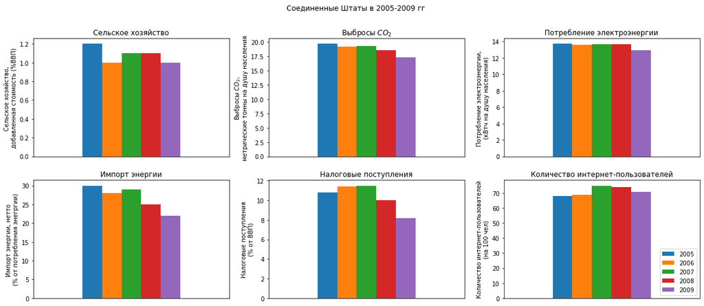

```python
fig, axes = plt.subplots(2, 3, figsize=(20, 8))
axe = axes.ravel()

USA.loc[ :, USA.columns.str.startswith('agriculture')].plot(
        kind='bar',
        rot=0,
        ax=axe[0],
    )
axe[0].set_ylabel('Сельское хозяйство, \nдобавленная стоимость (%ВВП)')
axe[0].set_title('Сельское хозяйство')

USA.loc[ :, USA.columns.str.startswith('co2')].plot(
        kind='bar',
        rot=0,
        ax=axe[1],
    )
axe[1].set_ylabel('Выбросы $CO_2$, \nметрические тонны на душу населения')
axe[1].set_title('Выбросы $CO_2$')

USA.loc[ :, USA.columns.str.startswith('electric_power')].plot(
        kind='bar',
        rot=0,
        ax=axe[2],
    )
axe[2].set_ylabel('Потребление электроэнергии, \n(кВтч на душу населения)')
axe[2].set_title('Потребление электроэнергии')

USA.loc[ :, USA.columns.str.startswith('energy_imports')].plot(
        kind='bar',
        rot=0,
        ax=axe[3],
    )
axe[3].set_ylabel('Импорт энергии, нетто \n(% от потребления энегргии)')
axe[3].set_title('Импорт энергии')

USA.loc[ :, USA.columns.str.startswith('tax_revenue')].plot(
        kind='bar',
        rot=0,
        ax=axe[4],
    )
axe[4].set_ylabel('Налоговые поступления\n(% от ВВП)')
axe[4].set_title('Налоговые поступления')

USA.loc[ :, USA.columns.str.startswith('internet_users')].plot(
        kind='bar',
        rot=0,
        ax=axe[5],
    )
axe[5].set_ylabel('Количество интернет-пользователей\n(на 100 чел)')
axe[5].set_title('Количество интернет-пользователей')
axe[5].legend(list(range(2005, 2010)), loc=4)
for i in range(6):
    axe[i].xaxis.set_visible(False)
for i in range(5):
    axe[i].get_legend().remove()

plt.suptitle('Соединенные Штаты в 2005-2009 гг')
plt.show()
```

#### **Вывод**

Итак, на данных графиках мы видим ожидаемую корреляцию между сельским хозяйством, потреблением энергии и выбросами $CO_2$.

Сельское хозяйсто, будучи одним из наиболее загрязняющих производств в плане выбросов $CO_2$ отреагировало на кризис снижением добавленной стоимости, что привело к снижению выбросов $CO_2$. Снижение потребления электроэнергии на фоне кризиса также положительно сказалось на экологической обстановке в США.

На второй линии графиков видна некоторая зависимость между импортом энергии и налоговыми поступлениями.

Можно предположить, что потенциальное снижение интернет-пользователей в 2009 году так же снизило количество потребляемой энергии, так как в 2009 году огромное количество работников банковского сектора, основная работа которых была связана с работой через Интернет, потеряла работу, что привело к логичному снижению интернет-пользователей, и как следствие снижению потребления электроэнергии.